# HTML report Pipeline Reproducibility Test

Jishu Xu

27 April, 2018

# Purpose

In this section, first, we calculate the individual pipeline’s reproducibility between single cell and bulk samples by using group t-test and p-values of each genes are returned. The fold changes between single cell and bulk samples are also calculated. Then we compare this reproducibility between pipelines and then we focus on genes which show inconsistent reproducibility between pipelines and category them by their gene annotation.

# Input data

The key input data for this test are the data matrix generated by two pipelines, they can be gene counts matrix or TPM, FPKM matrix. The detail of input data are listed below

- matrix1: data matrix from pipeline, such as base pipeline.
- matrix2: data matrix from pipeline, such as updated pipeline.
- gtf_file: gene annotation file in gtf format.
- metadata_file: meta information about cells, such as cell type.
- output_prefix: output prefix or output name.

First load functions we will use in this test

```r
source("analysis_functions.R")
```

Here is the list of input parameters

```r
option_list <- list(
  make_option(
    "--matrix1",
    type = "character",
    default = NULL,
    help = "data matrix file name",
    metavar = "character"
  ),
  make_option(
    "--matrix2",
    type = "character",
    default = NULL,
    help = "updated data matrix file name",
    metavar = "character"
  ),
  make_option(
    "--gtf_file",
    type = "character",
    default = NULL,
    help = "gtf annotation file",
    metavar = "character"
  ),
  make_option(
    "--metadata_file",
    type = "character",
    default = NULL,
    help = "metadata file",
    metavar = "character"
  ),
  make_option(
    "--output_prefix",
    type = "character",
    default = NULL,
    help = "output prefix",
    metavar = "character"
  )
)
args<-strsplit(commandArgs(trailingOnly = TRUE),split=' ')
opt_parser <- OptionParser(option_list = option_list)
opt <- parse_args(opt_parser,args=args[[1]])
matrixfile1 <- opt$matrix1
matrixfile2 <- opt$matrix2
gtf_file <-  opt$gtf_file
meta_file <-  opt$metadata_file
grps <- opt$groups
output_name <- opt$output_prefix
```

# Parse Inputs

## Metadata

metadata records information related to this dataset, such as ‘cell lineage’,‘celltype’,‘is population’

```r
# parse metadata
meta <- read.delim(meta_file, sep = ',', header = T)
knitr::kable(head(meta))
```

| sra | cell | lineage | origin | cell_type |
| --- | --- | --- | --- | --- |
| SRR5676728 | neuron | Day 100 | human cortical spheroid-derived cell | sc |
| SRR5676729 | glia | Day 100 | human cortical spheroid-derived cell | sc |
| SRR5676730 | glia | Day 100 | human cortical spheroid-derived cell | sc |
| SRR5676731 | neuron | Day 100 | human cortical spheroid-derived cell | sc |
| SRR5676732 | glia | Day 100 | human cortical spheroid-derived cell | sc |
| SRR5676733 | neuron | Day 100 | human cortical spheroid-derived cell | sc |

## Load Data Matrix

Data matrix files are *.csv file and can be count, TPM or FPKM matrix. For benchmarking purpose, TPM would be optimal choice.

```r
# load matrix file
mat1 <- read.csv(matrixfile1)
mat2 <- read.csv(matrixfile2)
rownames(mat1)<-mat1[,1]
rownames(mat2)<-mat2[,1]
```

## Data Transformation

First, take log2 transformation then filter out cells with too low overall expression level, such as over all sum expression <10000

```r
# log2 transformation
mat1.log2 <- takelog2(mat1[,-c(1:2)])
mat2.log2 <- takelog2(mat2[,-c(1:2)])
# filter cells/samples if total expression less than 10000
mat1.d <- FilterCellsbyExp(mat1.log2, 10000)
mat2.d <- FilterCellsbyExp(mat2.log2, 10000)
```

Then we need to match data matrix with metadata by cell ID(SRAID).

```r
# parse meta data to match filtered data matrix
mlist1 <- match(colnames(mat1.d), meta$sra)
mlist2 <- match(colnames(mat2.d), meta$sra)
grp1 <- meta[mlist1, 'cell_type']
grp2 <- meta[mlist2, 'cell_type']
```

Finally, we have log2-transformed and filtered data matrix, which is matched with metadata.

# T-Test: SC vs Bulk

Here we carry out t-test between two groups, single cell (708 single cells ) vs bulk samples (20 bulk samples).

First, run T-test on base pipeline results

```r
test.res1 <- apply(mat1.d, 1, function(x) {
  RunTest(x = x, y = grp1, 'ttest')
})
# Print out header of table
knitr::kable(head(t(test.res1)))
```

|  | pvalue | a1 | a2 | n1 | n2 |
| --- | --- | --- | --- | --- | --- |
| ENSG00000000003.14 | 0.0000002 | 4.9182611 | 3.4013502 | 20 | 306 |
| ENSG00000000005.5 | 0.0115347 | 0.4687380 | 0.0124003 | 8 | 1 |
| ENSG00000000419.12 | 0.0000785 | 3.3577644 | 2.2967478 | 20 | 218 |
| ENSG00000000457.13 | 0.0000000 | 2.1497045 | 0.2851475 | 20 | 46 |
| ENSG00000000460.16 | 0.0000000 | 3.3578904 | 0.2826762 | 20 | 36 |
| ENSG00000000938.12 | 0.1158833 | 0.0152073 | 0.0000000 | 3 | 0 |

Then, run ttest on updated pipeline results

```r
test.res2 <- apply(mat2.d, 1, function(x) {
  RunTest(x = x, y = grp2, 'ttest')
})
# Print out header of table
knitr::kable(head(t(test.res2)))
```

|  | pvalue | a1 | a2 | n1 | n2 |
| --- | --- | --- | --- | --- | --- |
| ENSG00000000003.14 | 0.0000001 | 4.9202449 | 3.3668634 | 20 | 311 |
| ENSG00000000005.5 | 0.0081239 | 0.4813145 | 0.0122140 | 9 | 1 |
| ENSG00000000419.12 | 0.0000374 | 3.3931824 | 2.2985308 | 20 | 217 |
| ENSG00000000457.13 | 0.0000000 | 2.1452365 | 0.2914698 | 20 | 53 |
| ENSG00000000460.16 | 0.0000000 | 3.3866182 | 0.3255739 | 20 | 66 |
| ENSG00000000938.12 | 0.1159863 | 0.0138766 | 0.0000000 | 3 | 0 |

# Visualize T-test Results

Now we have two sets of t-test results from two pipeline. Next we will visualize them by using scatterplot.

## Fold Changes

To visualize this comparison, we first calculate fold change between single cell and bulk samples of two pipeline then we plot them as xy-scatterplot,

- x-axis represents foldchange from base pipeline
- y-axis represents foldchange form updated pipeline.

```r
# extract foldchange from data matrix
res1 <- data.frame(t(test.res1))
res2 <- data.frame(t(test.res2))
fc1 <- res1$a1 - res1$a2
names(fc1) <- rownames(res1)
fc2 <- res2$a1 - res2$a2
names(fc2) <- rownames(res2)
```

## Color Schema of Comparison

We define the following color schema:

- Consistent genes in both pipeline
- Inconsistent genes in base but not in updated
- Inconsistent genes not in base but in updated
- Consistent genes not in base or updated

Next we convert pvalue to color schema.

```r
# convert p value
res1$pvalue <-
  factor(ifelse(res1$pvalue > 0.01 | is.na(res1$pvalue), "Base.insig", "Base.sig"))
res2$pvalue <-
  factor(ifelse(res2$pvalue > 0.01 | is.na(res2$pvalue), "Updated.insig", "Updated.sig"))
gcols <- paste(res1$pvalue, res2$pvalue, sep = ',')
# create data frame
df <- merge(fc1, fc2, by = 'row.names')
colnames(df) <- c('ensID', 'Base', 'Updated')
df['groups'] <- gcols
```

Then use ‘ggpubr’ package to visualize the comparison.

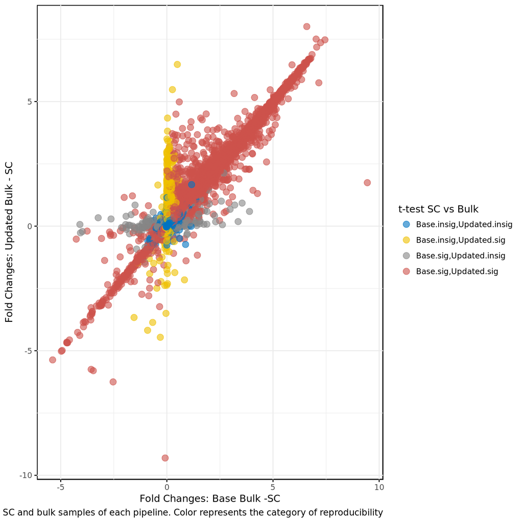

```r
sp <-
  ggscatter(
    df,
    x = 'Base',
    y = 'Updated',
    color = "groups",
    size = 3,
    alpha = 0.6,
    palette = "jco",
    ggtheme = theme_minimal(),
    legend.title = "t-test SC vs Bulk",
    caption = "Scatterplot of foldchanges between SC and bulk samples of each pipeline. Color represents the category of reproducibility",
    xlab = "Fold Changes: Base Bulk -SC",
    ylab = "Fold Changes: Updated Bulk - SC"
  ) + border()
sp
```

## Inconsistent Genes

It would be more interesting to find out what type of genes are inconsistent between pipelines in term of their biotype. First we group these inconsistent genes in the following way:

- Inconsistent genes 1: significant genes in base pipeline but not significant in updated pipeline.
- Inconsistent genes 2: not significant genes in base pipeline but significant updated pipeline

```r
# parse out two inconsistent gene groups
df.base <- subset(df, df$groups %in% c("Base.sig,Updated.insig"))
df.updated <- subset(df, df$groups %in% c("Base.insig,Updated.sig"))
```

Then query gene annotation based on ensID of inconsistent genes.

```r
# parse out gene annotation
genes <- ParseGene(gtf_file)
annt1 <- subset(genes, genes$gene_id %in% df.base$ensID)
annt2 <- subset(genes, genes$gene_id %in% df.updated$ensID)
```

Generate total counts table by gene annotation/biotype.

```r
tb1 <- table(annt1$gene_type)
tb2 <- table(annt2$gene_type)
```

Now we have two vectors of counts, one is for ‘Inconsistent genes 1’ and another is ‘Inconsistent genes 2’. For visualization purpose, we would give negative values to one of the count vectors.

```r
# assign negetive value to one of the vectors
tb <- rbind(tb1, -1 * tb2)
rownames(tb) <-
  c('Base.sig,Updated.insig', 'Base.insig,Updated.sig')
```

Then we can visualize inconsisitent genes by barplot.

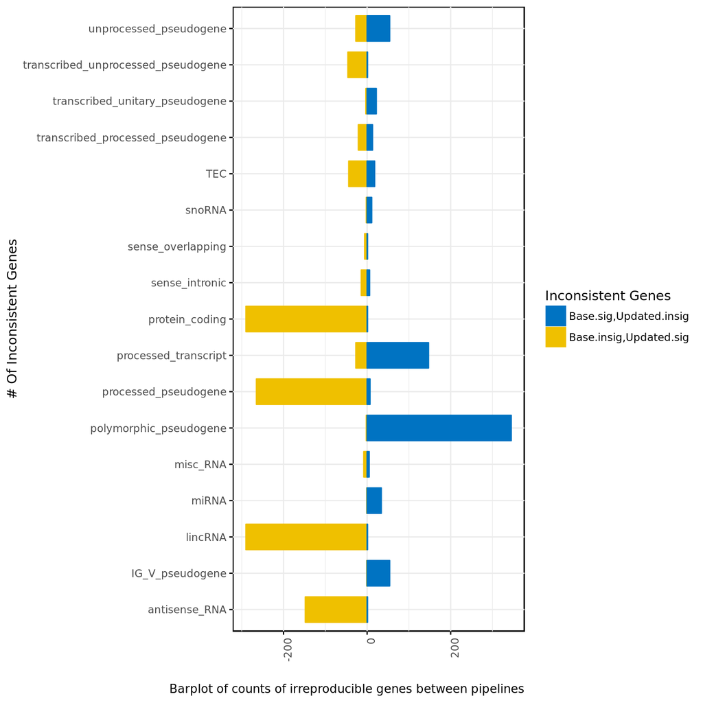

```r
mtb <- melt(tb)
pb <- ggbarplot(
  mtb,
  x = 'Var2',
  y = 'value',
  color = "Var1",
  fill = "Var1",
  # change fill color by FC
  x.text.angle = 90,
  # Rotate vertically x axis texts
  xlab = "# Of Inconsistent Genes",
  ylab = "",
  rotate = TRUE,
  caption = "Barplot of counts of irreproducible genes between pipelines",
  ggtheme = theme_minimal(),
  palette = "jco",
  legend.title = "Inconsistent Genes"
) + border()
pb
```

Finally, save t-test results into ‘.csv’ files.

```r
write.csv(
  res1,
  file = paste(
    output_name,
    "_base_ttest_res.csv",
    sep = ''),
    quote = F,
    row.names = F
)
write.csv(
  res2,
  file = paste(
    output_name,
    "_updated_ttest_res.csv",
    sep = ''),
  quote = F,
  row.names = F
)
```

# Converting R Script to HTML/PDF

If you did everyhing right, above this is the easy part. Simply render the script as desired with the `render` function from `rmarkdown`.  
Rscript -e ‘rmarkdown::render(“data_matrix_reproducibility.R”)’ —args “-—matrix1=base_matrix.csv,–matrix2=updated_matrix.csv,–gtf_file=gencode.v27.primary_assembly.annotation.gtf,–metadata_file=metadata.csv,–output_prefix=output_name”